# Práctica de la **Unidad 4. Visualización de datos**

## 5.6. Objetos geométricos

Después de definir los atributos gráficos que deseamos utilizar, debemos especificar uno o varios objetos geométricos para indicar cómo deben dibujarse los puntos de datos. Los objetos geométricos (o `geoms`) pueden ser puntos, líneas, barras, polígonos, áreas, histogramas, rectas con el mejor ajuste, entre otros. Cuál utilizar [dependerá del tipo y total de variables de datos que querramos representar y qué mensaje querramos comunicar con la visualización](https://sarahiaguilar.github.io/R-4-SocialSci/cheatsheets/data-visualization.pdf).

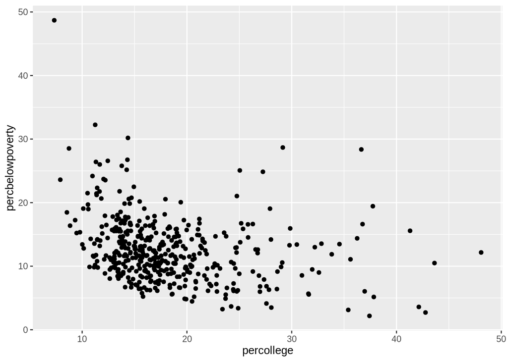

```r
ggplot(data = mw) +
  aes(x = percollege, y = percbelowpoverty) +
  geom_point()
```

Los objetos geométricos tienen sus propios parámetros para ajustar sus atributos gráficos.

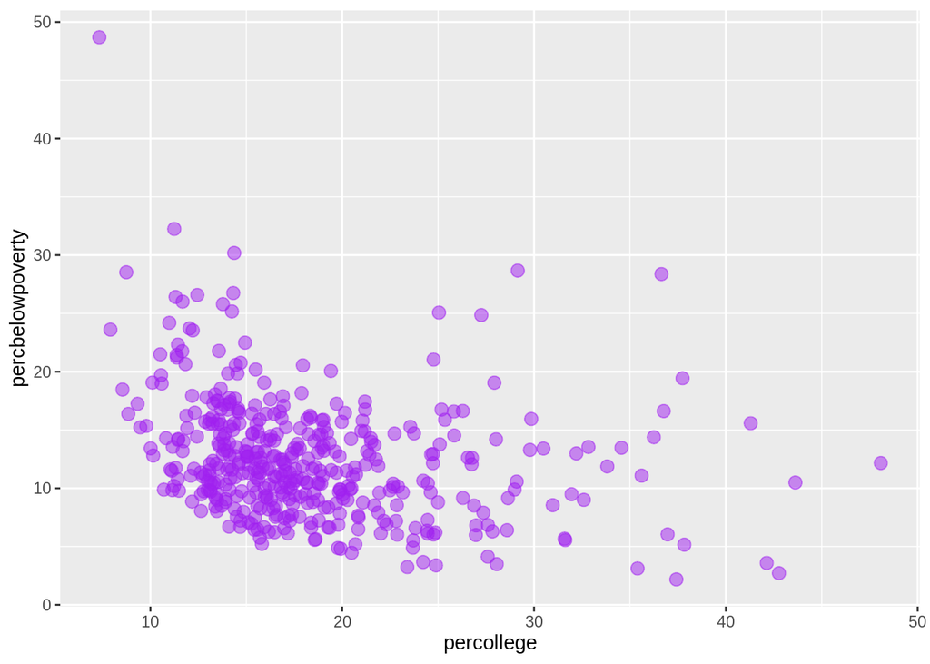

```r
ggplot(data = mw) +
  aes(x = percollege, y = percbelowpoverty) +
  geom_point(color = "purple", alpha = 0.50, size = 3)
```

Es posible agrupar cuantos objetos geométricos querramos.

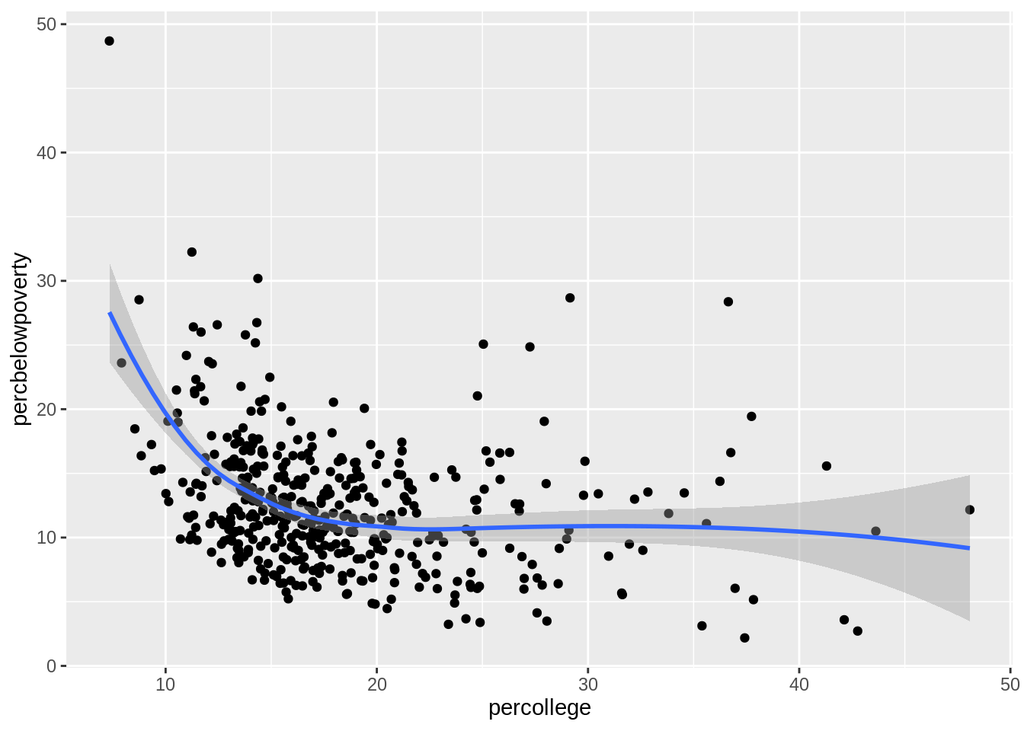

```r
ggplot(data = mw) +
  aes(x = percollege, y = percbelowpoverty) +
  geom_point() +
  geom_smooth()
```

Algunos `geoms` utilizan transformaciones estadísticas que aplican cálculos y agregaciones de forma implícita a los datos antes de graficarlos.

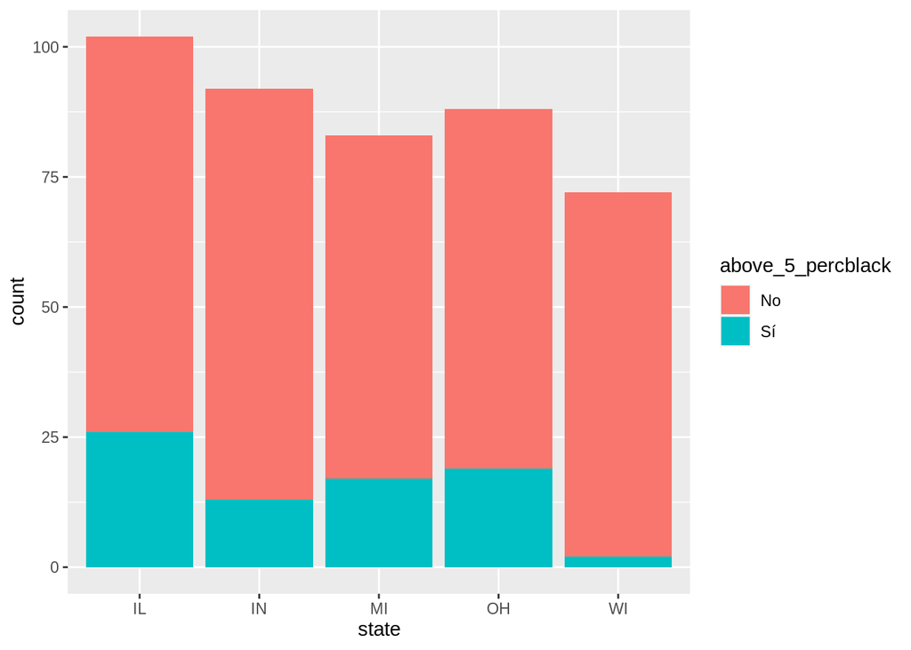

```r
mw[, above_5_percblack := ifelse(test = percblack >= 5, yes = "Sí", no = "No")]
ggplot(data = mw) +
  aes(x = state, fill = above_5_percblack) +
  geom_bar(stat = "count")
```

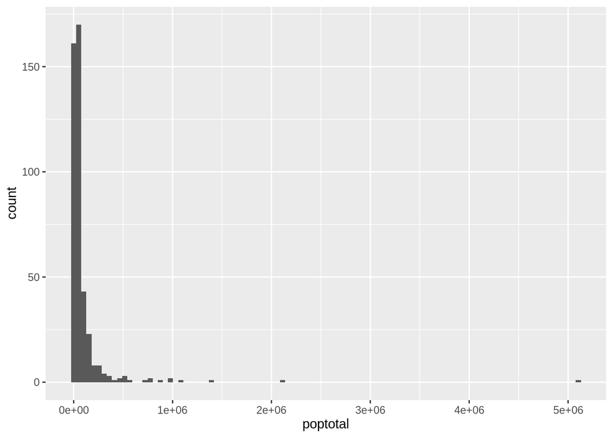

```r
ggplot(data = mw) +
  aes(x = poptotal) +
  geom_histogram(bins = 100)
```

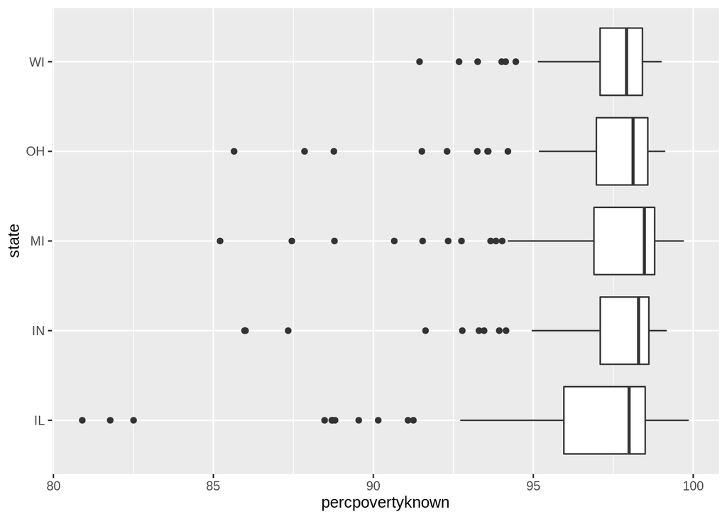

```r
ggplot(data = mw) +
  aes(x = percpovertyknown, y = state) +
  geom_boxplot()
```

💡 Sobre las visualizaciones de caja en ggplot2:

- Cada línea vertical representa el cuartil 25, el 50 (la mediana) y el 75 respectivamente.
- La caja representa el rango intercuartílico (diferencia entre los percentiles 75 y 25).
- El límite izquiero del bigote izquierdo representa el valor mínimo de los datos que está dentro de 1.5 veces el rango intercuartílico por debajo del percentil 25.
- El límite derecho del bigote derecho representa el valor máximo de los datos que está dentro de 1.5 veces el rango intercuartílico sobre el percentil 75.
- Los puntos representan los valores atípicos, que se consideran cualquier valor inferior a 1.5 veces el rango intercuartílico sobre el percentil 75 o cualquier valor izquierdo a 1.5 veces el rango intercuartílico bajo el percentil 25.

Igualmente, es posible especificar objetos primitivos, es decir, objetos geométricos independientes de los datos.

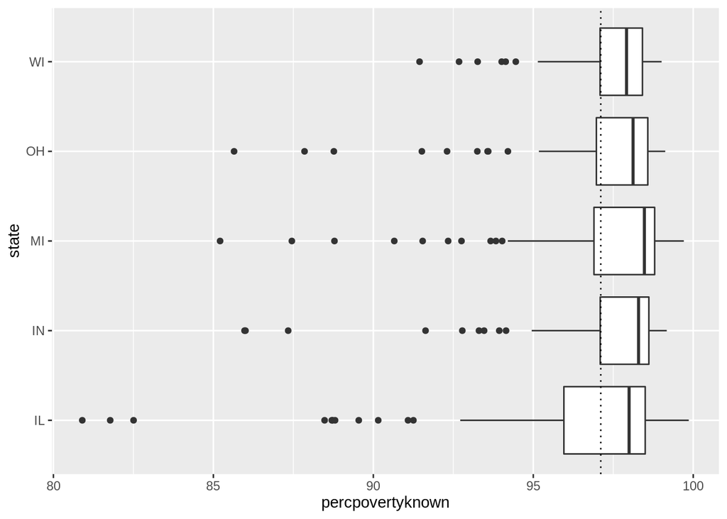

```r
mu <- mean(mw[, percpovertyknown])
ggplot(data = mw) +
  aes(x = percpovertyknown, y = state) +
  geom_boxplot() +
  geom_vline(xintercept = mu, linetype = "dotted")
```

## 5.7. Escalas

Cada vez que asignamos variables de datos a atributos gráficos (con la función `aes()`), ggplot2 usa una escala particular para determinar el rango de valores al que se deben asignar los datos.

Por ejemplo, cuando especificamos: `ggplot(data = mw) + aes(x = percollege, y = percbelowpoverty) + geom_point()`, ggplot2 agrega automáticamente una escala predeterminada para cada asignación.

Cada escala se puede representar mediante una función con el siguiente nombre: `scale_`, seguido del nombre del atributo estética, seguido de un `_` y seguido el tipo de dato de la variable de la escala.

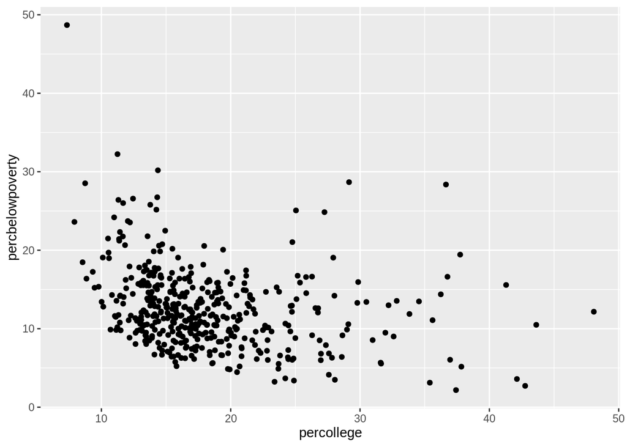

```r
ggplot(data = mw) +
  aes(x = percollege, y = percbelowpoverty) +
  geom_point() +
  scale_x_continuous() +
  scale_y_continuous() +
  scale_colour_discrete()
```

Si bien las escalas predeterminadas funcionan bien, es posible agregar explícitamente diferentes escalas para reemplazar las predeterminadas.

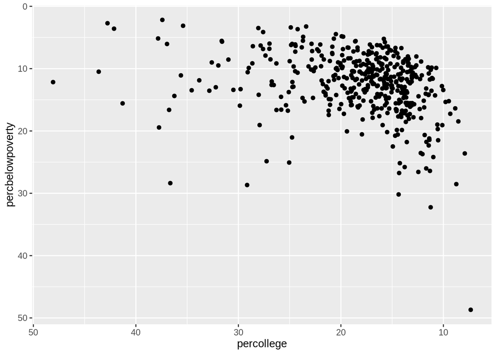

```r
ggplot(data = mw) +
  aes(x = percollege, y = percbelowpoverty) +
  geom_point() +
  scale_x_reverse() +
  scale_y_reverse()
```

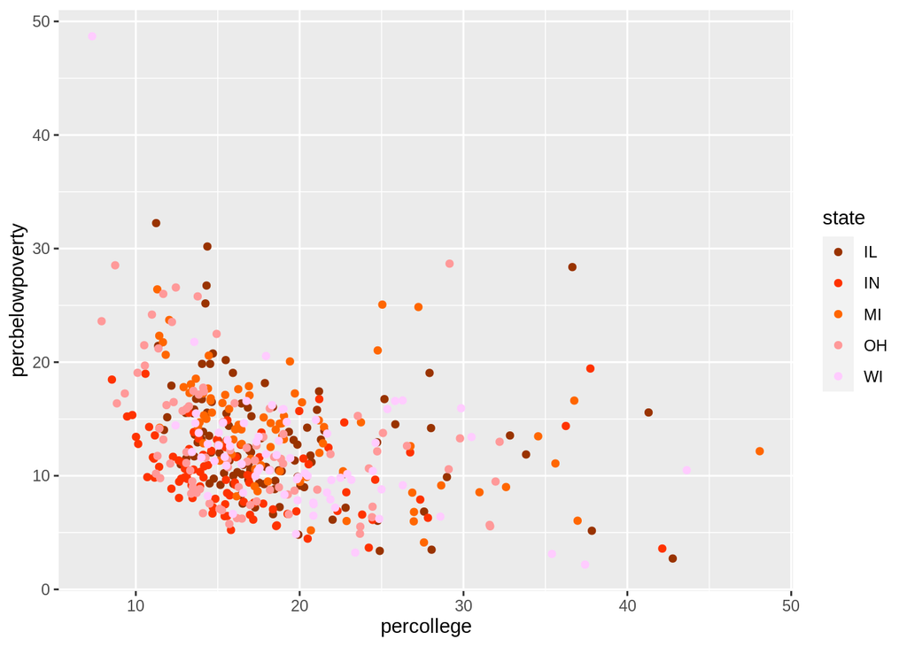

```r
ggplot(data = mw) +
  aes(x = percollege, y = percbelowpoverty, color = state) +
  geom_point() +
  scale_color_manual(values = c("#993300", "#ff3300", "#ff6600", "#ff9999", "#ffccff")) # Colores definidos con su código hexadecimal
```

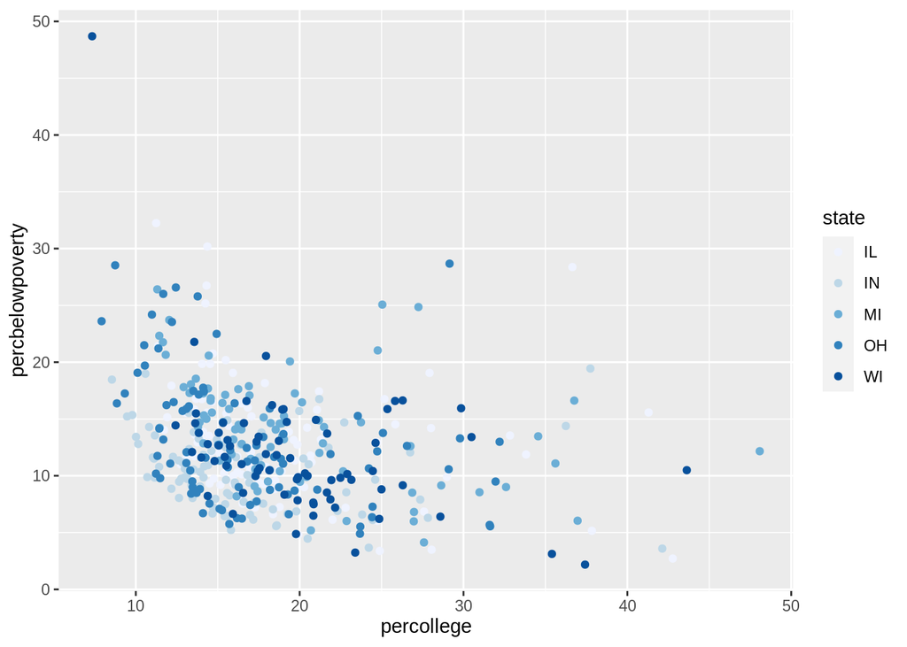

```r
ggplot(data = mw) +
  aes(x = percollege, y = percbelowpoverty, color = state) +
  geom_point() +
  scale_color_brewer(palette = "Blues") # https://rdrr.io/cran/RColorBrewer/man/ColorBrewer.html
```

## 5.8. Facetas

Las facetas (o `facets`) nos permiten agrupar datos por variables y luego graficar cada grupo individualmente un panel independiente, pero en la misma visualización (imagen).

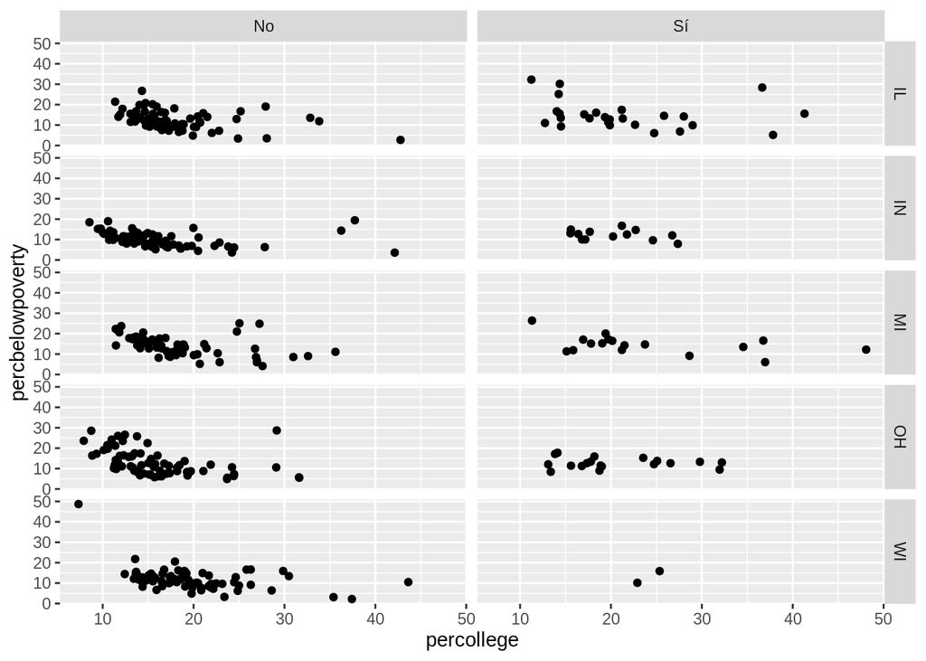

```r
ggplot(data = mw) +
  aes(x = percollege, y = percbelowpoverty) +
  geom_point() +
  facet_grid(facets = "state~above_5_percblack")
```

## 5.9. Coordenadas

El sistema de coordenadas define cómo se asignan los puntos de datos a ubicaciones gráficos 2D en el plano. Elegir el sistema de coordenadas correcto puede mejorar considerablemente la legibilidad de las visualizaciones de datos.

Al igual que con las escalas, los sistemas de coordenadas se especifican con funciones que comienzan con `coord_` y se agregan como una capa.

Existe una serie de diferentes sistemas de coordenadas, que incluye:

- `coord_cartesian()` es el sistema de coordenadas cartesianas predeterminado, donde especifica los valores x y y. Este sistema de coordenadas es el predeterminado, por lo que no es necesario agregarlo en cada ocasión como capa. No obstante, especificar sus parámetros permite establecer límites en los ejes, y por tanto, acercar o alejar la visualización.
- `coord_flip()` es un sistema de coordenadas cartesianas con la x y la y volteadas.
- `coord_polar()` es un sistema de coordenadas polares.

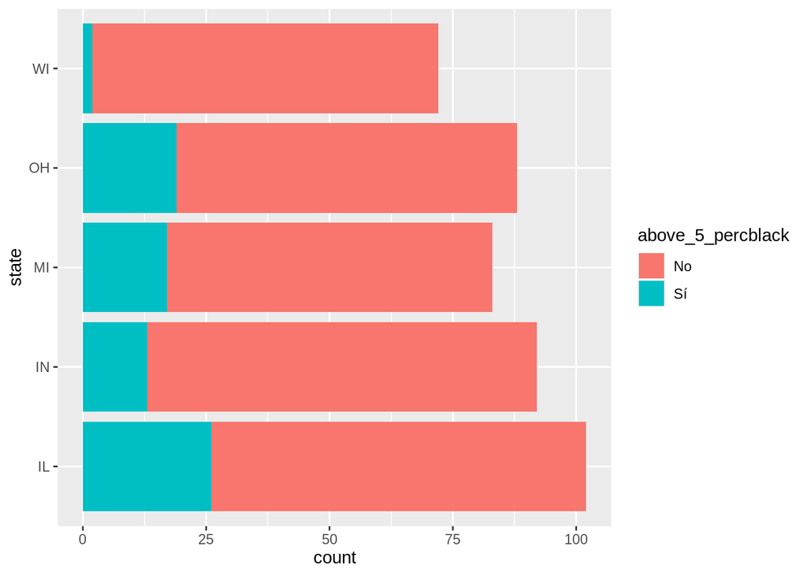

```r
ggplot(data = mw) +
  aes(x = state, fill = above_5_percblack) +
  geom_bar(stat = "count") +
  coord_flip()
```

## 5.10. Temas

Otra excelente manera de mejorar la presentación de nuestras visualizaciones de datos es elegir un tema no predeterminado para que nuestras visualizaciones se destaquen, haciéndolos más bonitas y vibrantes. ggplot2 incluye [varios temas entre los que podemos elegir](https://ggplot2.tidyverse.org/reference/ggtheme.html).

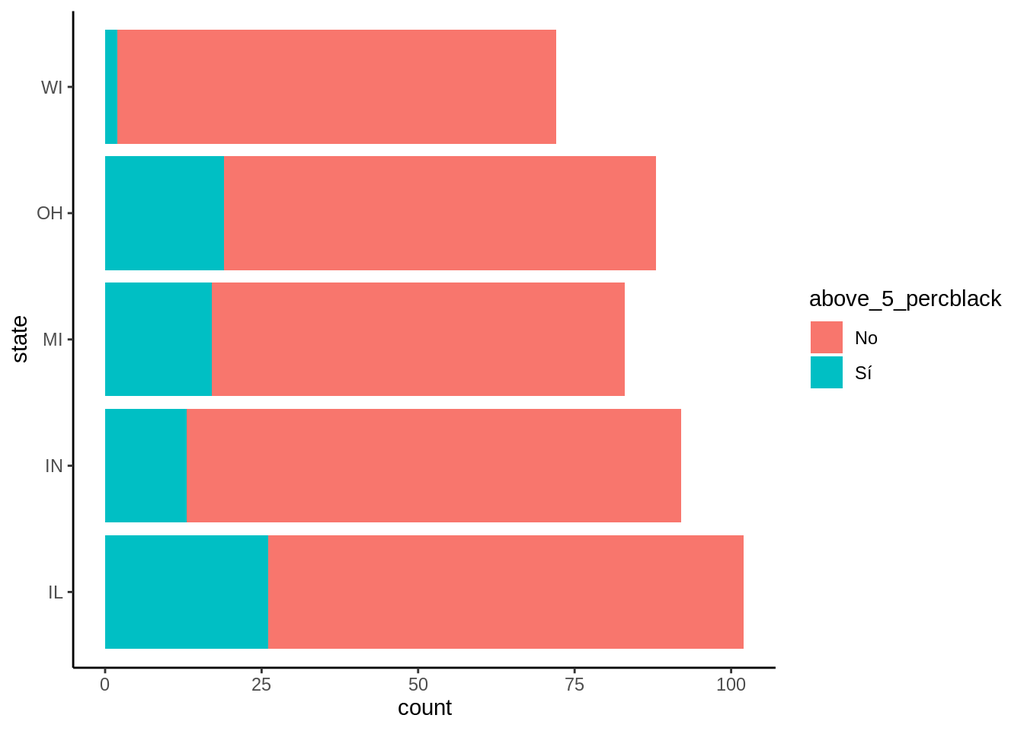

```r
ggplot(data = mw) +
  aes(x = state, fill = above_5_percblack) +
  geom_bar(stat = "count") +
  coord_flip() +
  theme_classic()
```

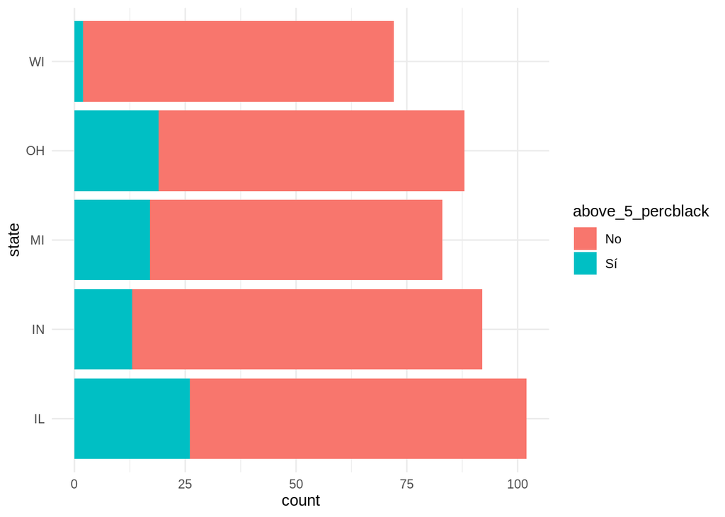

```r
ggplot(data = mw) +
  aes(x = state, fill = above_5_percblack) +
  geom_bar(stat = "count") +
  coord_flip() +
  theme_minimal()
```

## 5.10. Temas

Otra excelente manera de mejorar la presentación de sus visualizaciones de datos es elegir un tema no predeterminado para que los elementos gráficos destaquen, haciéndolos más vibrantes y congruentes con el tipo variables de datos que querramos representar y qué mensaje querramos comunicar con la visualización. ggplot2 incluye [varios temas entre los que podemos elegir](https://ggplot2.tidyverse.org/reference/ggtheme.html).

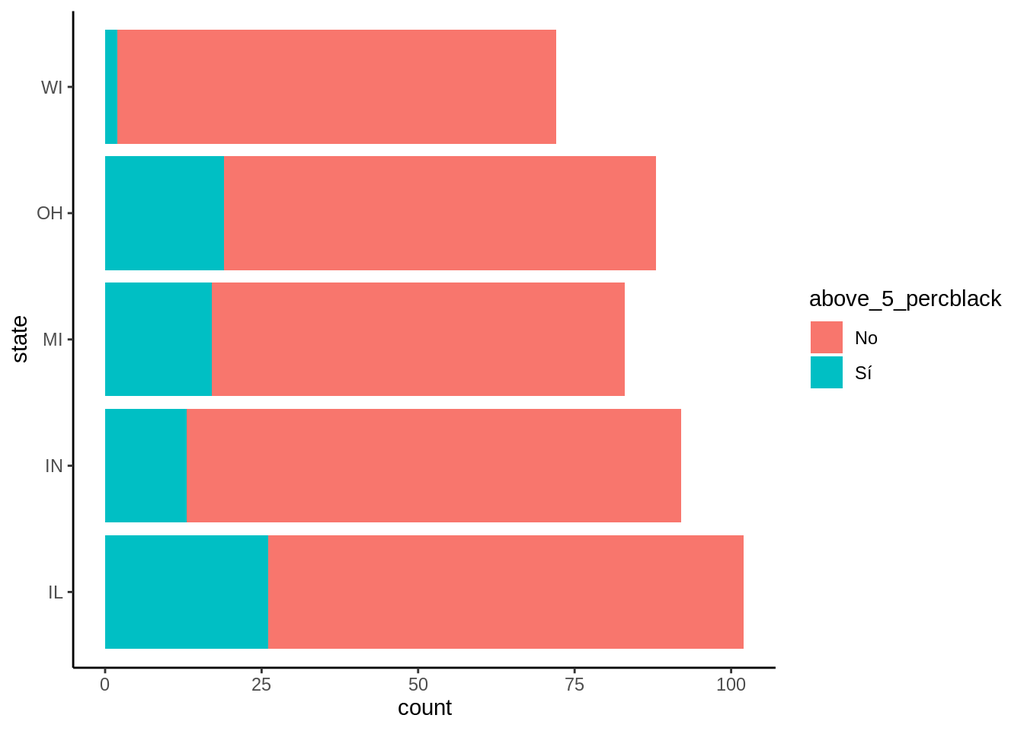

```r
ggplot(data = mw) +
  aes(x = state, fill = above_5_percblack) +
  geom_bar(stat = "count") +
  coord_flip() +
  theme_classic()
```

## 5.11. Títulos, etiquetas y anotaciones

Los títulos, etiquetas y anotaciones textuales (en el lienzo, los ejes, los objetos geométricos y la leyenda) son una parte importante para hacer que una visualización sea comprensible y que comunique información de manera eficiente. Aunque no es una parte explícita de la gramática de gráficos, se consideraría una variante de objeto geométrico.

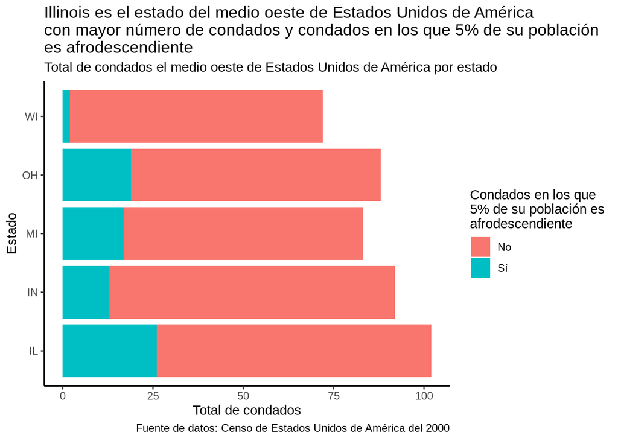

```r
ggplot(data = mw) +
  aes(y = state, fill = above_5_percblack) +
  geom_bar(stat = "count") +
  theme_classic() +
  labs(x = "Total de condados",
       y = "Estado",
       title = "Illinois es el estado del medio oeste de Estados Unidos de América\ncon mayor número de condados y condados en los que 5% de su población\nes afrodescendiente",
       subtitle = "Total de condados el medio oeste de Estados Unidos de América por estado",
       fill = "Condados en los que\n5% de su población es\nafrodescendiente",
       caption = "Fuente de datos: Censo de Estados Unidos de América del 2000")
```

## 5.12. Exportación

Una vez que la visualización esté completa, este se puede exportar desde la ventana de *Plots* de forma manual o con la función `ggsave()` de forma programática después de asignar la visualización a un objeto.

```r
v <- ggplot(data = mw) +
  aes(y = state, fill = above_5_percblack) +
  geom_bar(stat = "count") +
  theme_classic() +
  labs(x = "Total de condados",
       y = "Estado",
       title = "Illinois es el estado del medio oeste de Estados Unidos de América\ncon mayor número de condados y condados en los que 5% de su población\nes afrodescendiente",
       subtitle = "Total de condados el medio oeste de Estados Unidos de América por estado",
       fill = "Condados en los que\n5% de su población es\nafrodescendiente",
       caption = "Fuente de datos: Censo de Estados Unidos de América del 2000")
ggsave("./viz/myviz.svg", v, width = 10, height = 5)
```

A pesar de que ggplot2 es una herramienta de visualización de datos robusta, no se tiene un control absoluto de todos los elementos gráficos. Por ello, es recomendable importar la visualización como svg, un formato de archivo vectorial, que después es posible cargar en programas de edición de imágenes digitales alternas para terminar de ajustar los mínimos detalles.

💡 [Gimp](https://www.gimp.org/) e [Inkscape](https://inkscape.org/es/) son programas de edición de imágenes digitales gratuitos en los que resulta muy cómodo el ajuste de visualizaciones de datos.